# Coursework Report

*N* removed NAs: 6

*N* removed <18: 19

**Correct typo age:** 18

*N* total clean: 143

| Group | *N* | *M*<sub>age</sub> | % green |
| --- | --- | --- | --- |
| Control | 68 | 21.0 | 31.9 |
| Experim | 75 | 21.1 | 51.1 |

| Gender | *N* | *M*<sub>age</sub> | % green |
| --- | --- | --- | --- |
| Female | 67 | 20.7 | 40.8 |
| Male | 50 | 21.0 | 44.0 |
| Other | 26 | 22.0 | 41.0 |

**Main analysis results**

**car:**  
χ<sup>2</sup>(1) = 5.1, *p* = .024

**cleaner:**  
χ<sup>2</sup>(1) = 6.76, *p* = .009

**dishwasher:**  
χ<sup>2</sup>(1) = 2.69, *p* = .101

[interactive chart not shown]

[figure not shown]

[interactive chart not shown]

# Coursework Report

Analysing Data, Spring 2020

# Methods

## Participants

Table 1 shows a breakdown of the particpants ages:

| mean | sd | min | max |
| --- | --- | --- | --- |
| 21.1 | 2.13 | 18 | 27 |

## Design

The study aimed to look at the effect that activation of status motives had on choices made regarding luxurious or proenvironmental green products. There were two between-subject conditions – status motives or a control condition. The participants read a short story depending on the condition they were in. The status motives group read a story about an individual’s first day at a new job which focussed on the desire for a promotion and the high-status items around the office. The other condition, the control, read another short story about losing a ticket to a concert, no status motives were primed. This set up the two main variables that the study tested. There was also an additional control condition where no story was read to make sure the story didn’t have an effect on the choices. After the story section the participants were then asked to choose between a luxurious or greener item for three products – a car, a household cleaner and a dishwasher. This was operationalised by ensuring that the products for both categories were of the same price and made by the same company. This minimised the effect of other confounding variables and biases.

The operationalised hypothesis was that the individuals in the status priming condition will chose significantly more of the green products than the individuals who read the neutral story. The null hypothesis is that there will be no statistically significant difference between the neutral and the status priming conditions product choices. I will use a Chi squared statistical analysis to test this hypothesis.

# Results

I performed 3 chi-squared analyses to look at the relationship between the story condition and the product choices the particpants made after reading the story. The particpants were split into either the experimetnal condition where a story caused the particpant to think about their position in a workplace and the possibility of a promotion and the control condition where the character had lost their ticket (where no status motives were prompted).

Table 2 shows the distribition of product choices for the cleaner product:

|  | luxury | green |
| --- | --- | --- |
| control | 49 | 19 |
| experimental | 37 | 38 |

Figure 1. shows the story condition by product choice. The graph clearly shows that in the control condition there were significantly more particpants chosing the luxury product than in the control condition.

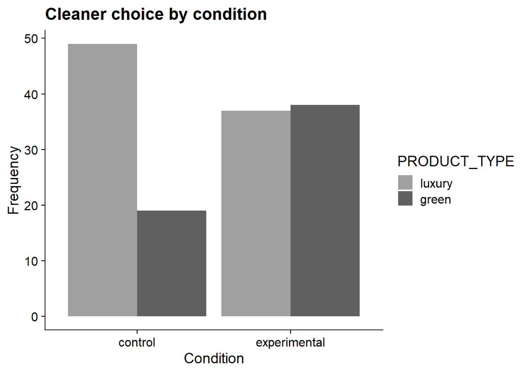

These graphs show the choices made by the particpants in the dishwasher and the car cateorgies. The difference in significance is between the car and dishwasher when the graphs are compared.

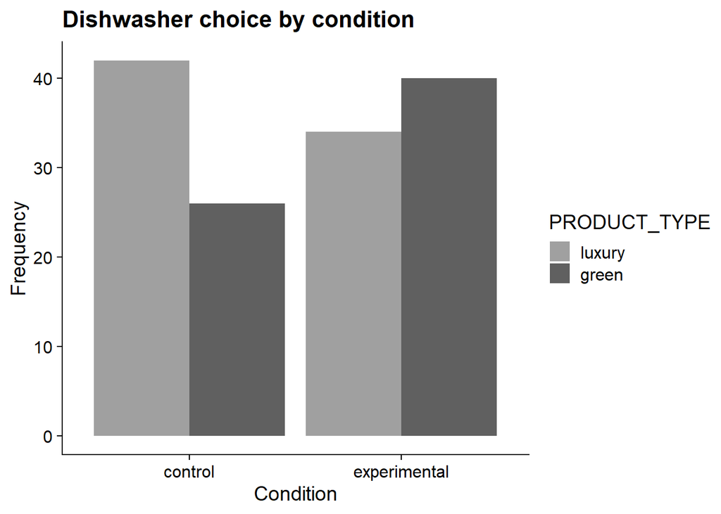

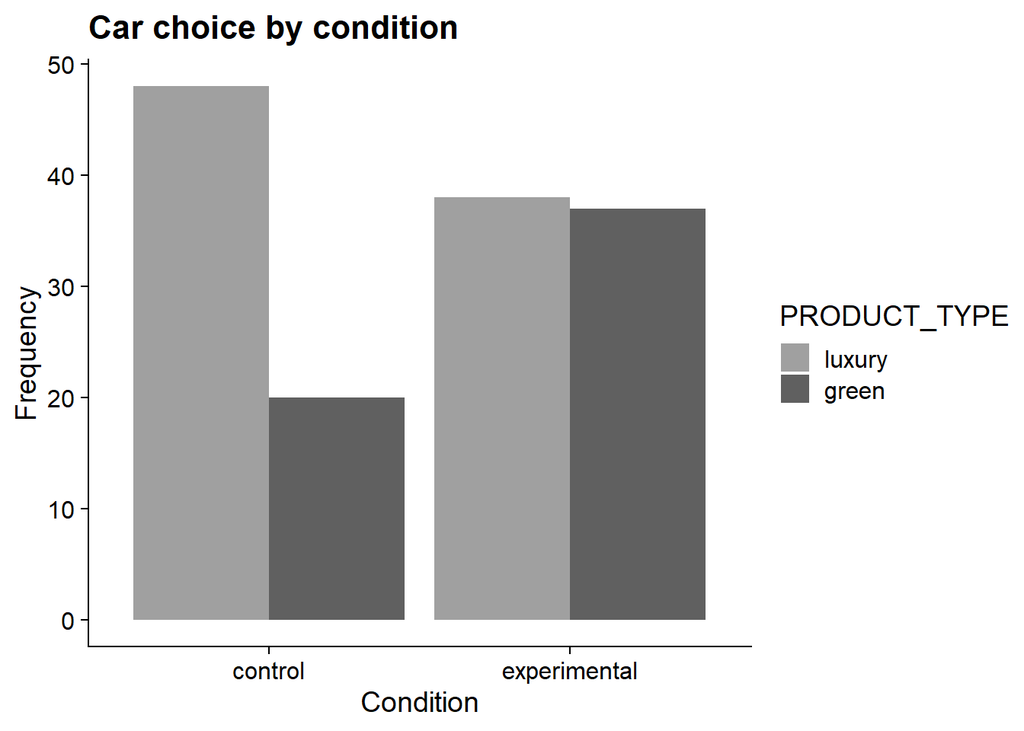

# Discussion

These results are powerful in contributing to the research area as they, both my results and those obtained in the original study, show the influence that the presence of thoughts about status and social position can have on people’s product choices. This could be a very powerful way to help our society being a greener place in general. This could also be applied to areas such as healthy eating or promoting exercise.

The standardisation of this study is a definite strength, with the products that the participants were given to choose between all being from the same brand and same price with only three different defining elements for the participants to choose from. This meant that individual preferences about brands or price marks could not have influenced their decision, meaning that the effect of the status motives was clear to see.

The study, however, does have some limitations, for example, the sample being very limited as all the participants were relatively young in age - with the oldest only being 27. This therefore only represents a very small section of our population and maybe this generation is more focussed on status motives and the opinions of others. This decreases the generalisability of the research. Other research, however, has been carried out looking at different age groups. For example, Gordon-Wilson et al (Gordon-Wilson & Modi, 2015) looked into the differences between older age groups, with a focus on those over 50, they found consumers between 50 and 64 performed the greenest behaviour than those age 65 to 74. The participants aged 75 or older performed the lowest levels of green behaviour. This supports my point that there may be differences between age groups and that this is something that needs to be researched in more detail, e.g. what about people from the ages of 30 to 50.

The main question in this area of research is the power of status motives, and whom they affect the most as well as how they cause people’s choices to shift. Research has proven that status motives appear to have power over people’s behaviours across different cultures, ages and genders (Anderson et al., 2015). This indicates the power of the desire for status being universal across the human race. Anderson’s research into the universality of status motives outlined that status level appears to affect individual’s well-being, with those with a higher status having higher levels of self-esteem.

Future research into this area could be very powerful way for brands to market their products as they can promote the psychological gains you would achieve for purchasing this product – for example, the ‘warm glow’ as described by Hartmann (Hartmann & Apaolaza-Ibáñez, 2012). This is achieved by making choices that benefit to the common good, not just yourself. If brands are able to target elements of our psyche such as these, they could profit greatly. Research into self-less behaviour in the workplace found that individuals often performed an act of self-sacrifice in order to build up and maintain their status within the office, A self-sacrificing or self-effacing behaviour can be an effective strategy to manifest superiority (Park et al., 2017). More research into the power of status motives could be extremely useful in understanding workplace dynamics and the subtleties of working in a group to ensure that every member of a group feels they have the appropriate status, and voice in the group.

I think that the idea of increased status does prompt people to make greener choices because my results agreed with those produced by Griskevicius, as well as the rest of the research in this field. Multiple studies have shown the power of making people think about their position in society when making decisions. More research should be done with a wider range of participants - not just university students below the age of 30, this will help to understand more about this research area.

In conclusion, I have found that there is a relationship between the act of status priming and the consequent product choices made by participants. However, this is from a very limited sample, who may be more focussed on their position, than other groups in society and therefore these results cannot be relied on too greatly.

# References

Anderson, C., Hildreth, J. A. D., & Howland, L. (2015). Is the desire for status a fundamental human motive? A review of the empirical literature. Psychological Bulletin, 141(3), 574–601. https://doi.org/10.1037/a0038781

Gordon-Wilson, S., & Modi, P. (2015). Personality and older consumers’ green behaviour in the UK. Futures, 71, 1–10. https://doi.org/10.1016/j.futures.2015.05.002

Griskevicius, V., Tybur, J. M., & Van den Bergh, B. (2010). Going green to be seen: Status, reputation, and conspicuous conservation. Journal of Personality and Social Psychology, 98(3), 392–404. https://doi.org/10.1037/a0017346

Hartmann, P., & Apaolaza-Ibáñez, V. (2012). Consumer attitude and purchase intention toward green energy brands: The roles of psychological benefits and environmental concern. Journal of Business Research, 65(9), 1254–1263. https://doi.org/10.1016/j.jbusres.2011.11.001

Park, J., Chae, H., & Choi, J. N. (2017). The need for status as a hidden motive of knowledge-sharing behavior: An application of costly signaling theory. Human Performance, 30(1), 21–37. https://doi.org/10.1080/08959285.2016.1263636